# Common Probability Distributions

### Students t

Examining how the degrees of freedom change the shape of the student t distribution.

*As the degrees of freedom increase the $p$ increase at the mean $\mu$ of the bell curve making the standard deviation $\sigma$ smaller.*

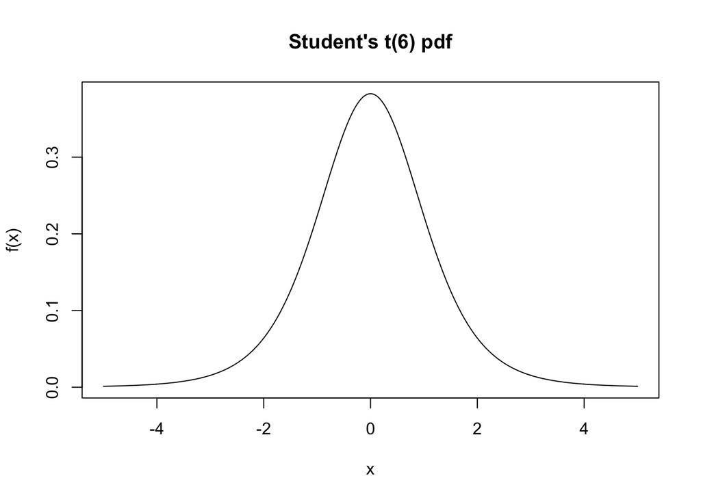

```r
x <- seq(-5, 5, 0.01)
plot(x, dt(x, 6), type = "l", ylab = "f(x)", main = "Student's t(6) pdf")
```

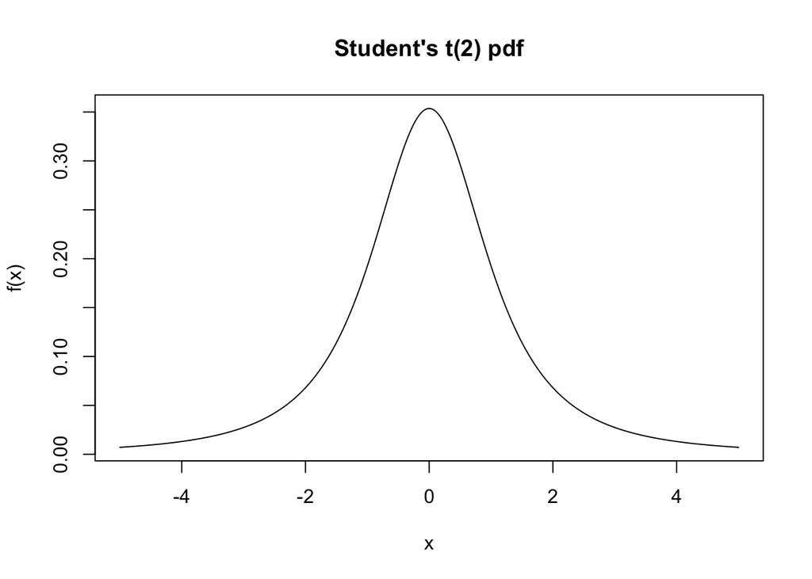

```r
plot(x, dt(x, 2), type = "l", ylab = "f(x)", main = "Student's t(2) pdf")
```

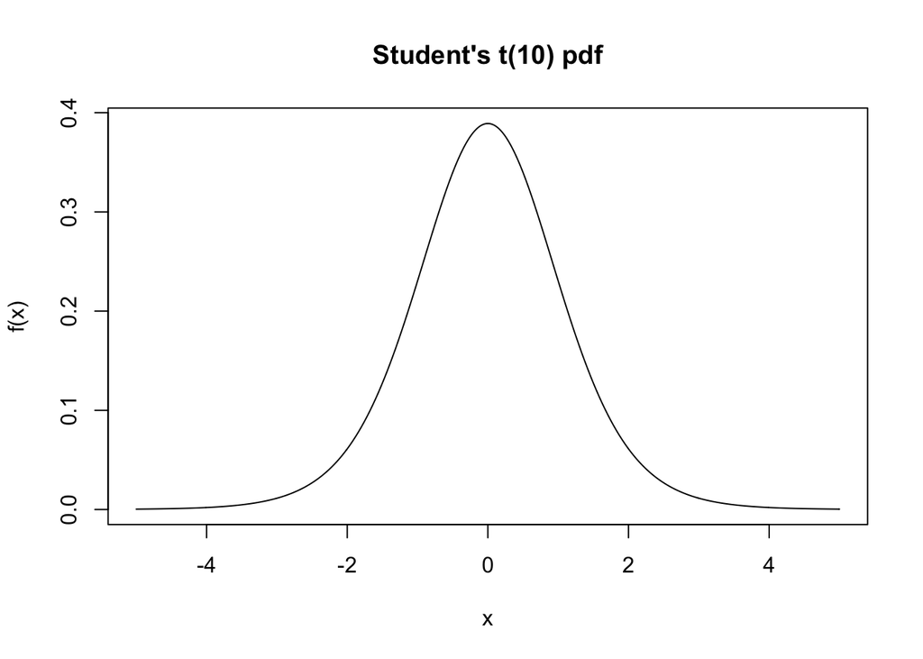

```r
plot(x, dt(x, 10), type = "l", ylab = "f(x)", main = "Student's t(10) pdf")
```

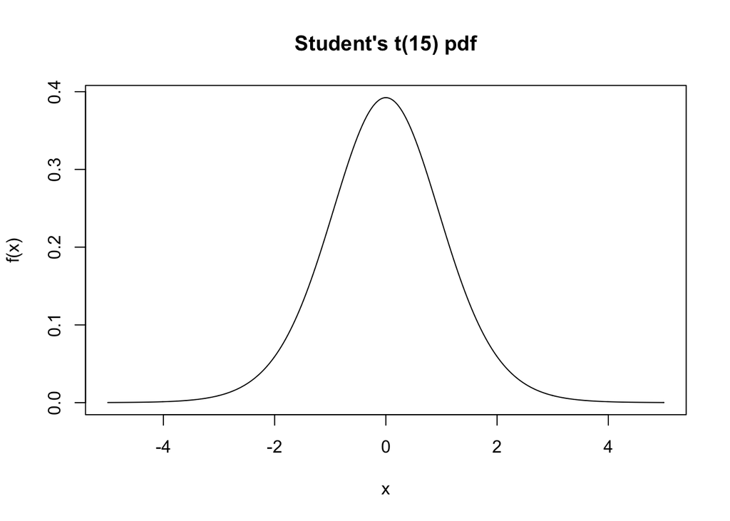

```r
plot(x, dt(x, 15), type = "l", ylab = "f(x)", main = "Student's t(15) pdf")
```

### F

See how the degrees of freedom (numerator and/or denominator) change the shape of the F distribution.

*As the degrees of freedom for the numerator tend to or exceed the denominator the curve shifts to the left on the X axis tending to zero on the Y axis. In addition the curve starts to flatten. Where as the denominator being much larger shifts ot the right on the X axis*

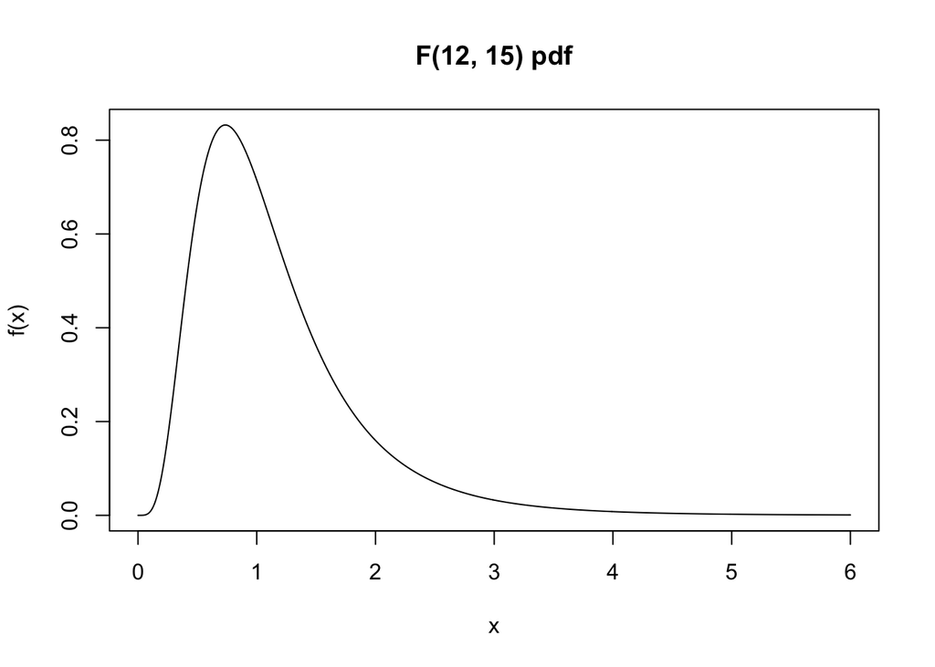

```r
x <- seq(0, 6, 0.01)
plot(x, df(x, 12, 15), type = "l", ylab = "f(x)", main = "F(12, 15) pdf")
```

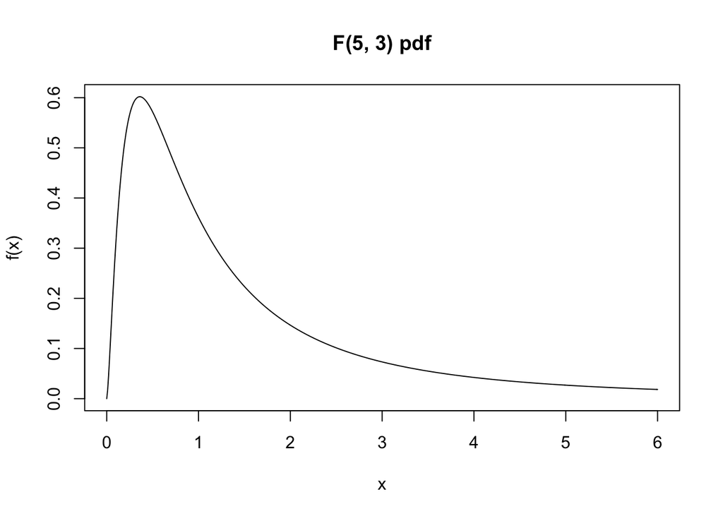

```r
plot(x, df(x, 5, 3), type = "l", ylab = "f(x)", main = "F(5, 3) pdf")
```

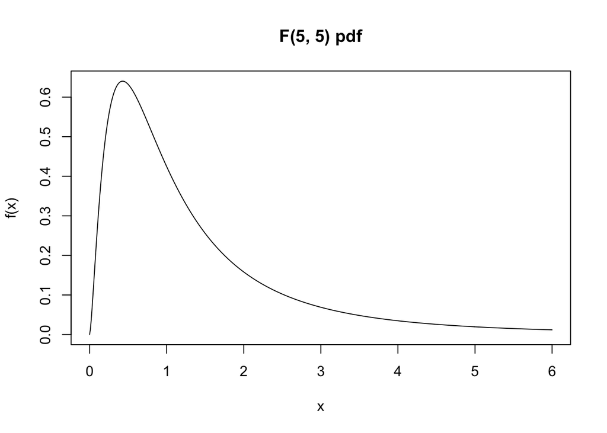

```r
plot(x, df(x, 5, 5), type = "l", ylab = "f(x)", main = "F(5, 5) pdf")
```

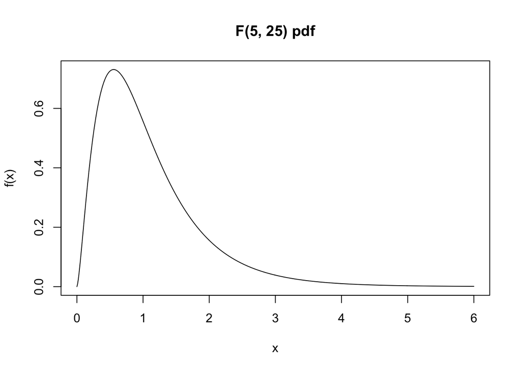

```r
plot(x, df(x, 5, 25), type = "l", ylab = "f(x)", main = "F(5, 25) pdf")
```